# Четверть медработников не зарабатывают и 10 тысяч рублей в месяц?

Такая история получилась после публикации результатов опроса, проведенного фондом “Здоровье”.

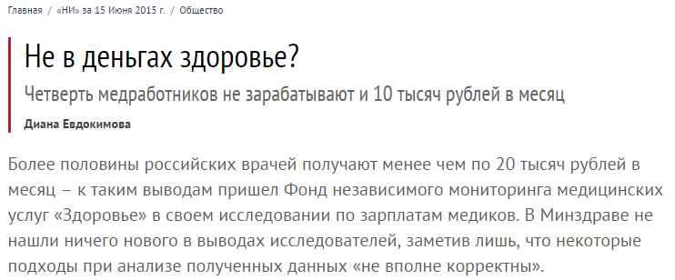

[newizv.ru](http://www.newizv.ru/society/2015-06-15/221137-ne-v-dengah-zdorove.html)

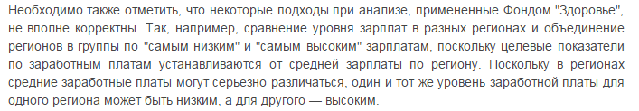

[rosminzdrav.ru](http://www.rosminzdrav.ru/news/2015/06/13/2393-informatsiya-o-zarabotnyh-platah-meditsinskih-rabotnikov)

## Данные

Мы можем проверить результаты опроса фонда “Здоровье” и заявления Минздрава.

Данные опроса доступны здесь: [fondzdorovie.ru](http://fondzdorovie.ru/monitoring/detail_monit.php?ID=1271). Нас интересует приложение с распределениями ответов по региону. Возьмем, например, третий лист с ответами на вопрос **“Укажите уровень Вашего дохода, получаемого на должности врача (медицинской сестры) (все ставки) в государственных медицинских организациях”**.

Также нам понадобятся данные о средних з/п по региону, попавших в опрос. Их можно взять у Росстата: [gks.ru](http://www.gks.ru/free_doc/new_site/population/trud/itog_monitor/itog-monitor1-15.html). Сдняя з/п по региону есть в каждой из этих таблиц, мы возьмем файл младшего медицинского персонала.

Все исходные данные, использованные здесь, продублированы на гитхабе: https://github.com/pased/med-income/tree/master/data/raw

Исходники всего анализа доступны здесь: https://github.com/pased/med-income/

## Анализ

Сразу же мы можем спросить: а какая средняя зарплата в этих регионах?

### Средняя зарплата в регионах и количество респондентов с з/п <10000 руб.

Респонденты, выбравшие ответ <10000. Колонки: регион, количество респондентов, средняя зп в регионе, количество ответов <10000руб. Ранжирование по средней з/п.

| region | total_n | mean_income | freq |
| --- | --- | --- | --- |
| Республика Дагестан | 149 | 17813 | 32 |
| Алтайский край | 82 | 18536 | 14 |
| Чувашская Республика - Чувашия | 47 | 19901 | 9 |
| Республика Северная Осетия - Алания | 57 | 20071 | 16 |
| Республика Мордовия | 63 | 20249 | 11 |
| Кировская область | 98 | 20637 | 16 |
| Ульяновская область | 58 | 21139 | 12 |
| Саратовская область | 59 | 21250 | 13 |
| Ставропольский край | 123 | 21381 | 20 |
| Пензенская область | 76 | 21767 | 14 |
| Волгоградская область | 99 | 22474 | 21 |
| Ростовская область | 125 | 22760 | 26 |
| Оренбургская область | 85 | 22794 | 8 |
| Тверская область | 52 | 23267 | 10 |
| Воронежская область | 62 | 23370 | 12 |
| Рязанская область | 60 | 23400 | 11 |
| Удмуртская Республика | 78 | 23524 | 10 |
| Астраханская область | 73 | 23675 | 20 |
| Республика Башкортостан | 171 | 24166 | 24 |
| Краснодарский край | 181 | 24739 | 31 |
| Самарская область | 133 | 25067 | 17 |
| Нижегородская область | 97 | 25137 | 16 |
| Омская область | 73 | 25656 | 14 |
| Тульская область | 70 | 26097 | 9 |
| Пермский край | 101 | 26271 | 12 |
| Новосибирская область | 172 | 26350 | 24 |
| Кемеровская область | 97 | 26652 | 16 |
| Республика Татарстан (Татарстан) | 134 | 27208 | 14 |
| Челябинская область | 219 | 28211 | 26 |
| Забайкальский край | 63 | 28350 | 5 |
| Свердловская область | 164 | 29288 | 16 |
| Иркутская область | 91 | 30581 | 11 |
| Томская область | 73 | 31414 | 9 |
| Приморский край | 102 | 31685 | 9 |
| Ленинградская область | 57 | 32817 | 4 |
| Красноярский край | 161 | 33155 | 16 |
| Хабаровский край | 56 | 35270 | 3 |
| Архангельская область | 50 | 35803 | 4 |
| Московская область | 575 | 38119 | 53 |
| Республика Коми | 45 | 38237 | 2 |
| г.Санкт-Петербург | 120 | 40916 | 9 |
| Мурманская область | 57 | 41962 | 5 |
| Республика Саха (Якутия) | 80 | 49464 | 2 |
| Тюменская область | 73 | 52187 | 6 |
| Ханты-Мансийский авт. округ-Югра | 99 | 55390 | 4 |
| г.Москва | 1069 | 58781 | 62 |

Первое, что бросается в глаза — очень маленькие выборки опроса: **медиана** = 83.5, **SD** = 162.36. Первый вывод, который можно сделать: *данные в отношении регионов не могут быть репрезентативными.* Странно, почему Минздрав начал свою критику опроса не с этого. Очевидно, что медработники с з/п <10000 руб. существуют, но сколько их в РФ мы не можем сказать.

Единственный регион с хорошей выборкой — г. Москва (n = 1069). Согласно данным опроса, доля медработников, выбравших ответ “<10000 руб.” в Москве составляет **5.8%**.

### Зарплата менее 20 000 руб.

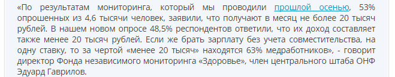

[fondzdorovie.ru](http://fondzdorovie.ru/monitoring/detail_monit.php?ID=1271)

Респонденты, выбравшие ответ <10000, 10000-14999, 15000-19999 и <20000. Колонки: регион, количество респондентов, средняя зп в регионе, количество ответов <20000руб. Ранжирование по средней з/п.

| region | total_n | mean_income | freq |
| --- | --- | --- | --- |
| Республика Дагестан | 149 | 17813 | 117 |
| Алтайский край | 82 | 18536 | 56 |
| Чувашская Республика - Чувашия | 47 | 19901 | 35 |
| Республика Северная Осетия - Алания | 57 | 20071 | 46 |
| Республика Мордовия | 63 | 20249 | 45 |
| Кировская область | 98 | 20637 | 52 |
| Ульяновская область | 58 | 21139 | 43 |
| Саратовская область | 59 | 21250 | 45 |
| Ставропольский край | 123 | 21381 | 75 |
| Пензенская область | 76 | 21767 | 55 |
| Волгоградская область | 99 | 22474 | 64 |
| Ростовская область | 125 | 22760 | 101 |
| Оренбургская область | 85 | 22794 | 51 |
| Тверская область | 52 | 23267 | 36 |
| Воронежская область | 62 | 23370 | 35 |
| Рязанская область | 60 | 23400 | 52 |
| Удмуртская Республика | 78 | 23524 | 43 |
| Астраханская область | 73 | 23675 | 70 |
| Республика Башкортостан | 171 | 24166 | 104 |
| Краснодарский край | 181 | 24739 | 142 |
| Самарская область | 133 | 25067 | 73 |
| Нижегородская область | 97 | 25137 | 61 |
| Омская область | 73 | 25656 | 48 |
| Тульская область | 70 | 26097 | 46 |
| Пермский край | 101 | 26271 | 54 |
| Новосибирская область | 172 | 26350 | 83 |
| Кемеровская область | 97 | 26652 | 54 |
| Республика Татарстан (Татарстан) | 134 | 27208 | 72 |
| Челябинская область | 219 | 28211 | 102 |
| Забайкальский край | 63 | 28350 | 28 |
| Свердловская область | 164 | 29288 | 74 |
| Иркутская область | 91 | 30581 | 38 |
| Томская область | 73 | 31414 | 44 |
| Приморский край | 102 | 31685 | 45 |
| Ленинградская область | 57 | 32817 | 20 |
| Красноярский край | 161 | 33155 | 65 |
| Хабаровский край | 56 | 35270 | 16 |
| Архангельская область | 50 | 35803 | 26 |
| Московская область | 575 | 38119 | 204 |
| Республика Коми | 45 | 38237 | 15 |
| г.Санкт-Петербург | 120 | 40916 | 35 |
| Мурманская область | 57 | 41962 | 17 |
| Республика Саха (Якутия) | 80 | 49464 | 22 |
| Тюменская область | 73 | 52187 | 30 |
| Ханты-Мансийский авт. округ-Югра | 99 | 55390 | 17 |
| г.Москва | 1069 | 58781 | 261 |

Как доля респондентов с ответом “<20 000 руб.” относиться к средней з/п в регионе?

lvl - доля респондентов, ответивших <20 000 руб.

| region | mean_income | lvl |
| --- | --- | --- |
| Республика Дагестан | 17813 | 78.5 |
| Алтайский край | 18536 | 68.3 |
| Чувашская Республика - Чувашия | 19901 | 74.5 |

На фоне таких результатов критика Минздрава становится еще более загадочной!

## Регионы со средней з/п меньше среднероссийской (31 566 руб.)

Регионы со средней з/п >20 000 руб. и долей респондентов с з/п <20 000 руб., превышающей 75%. lvl - доля респондентов, ответивших <20 000 руб. Ранжирование по доле респондентов.

| region | mean_income | lvl |
| --- | --- | --- |
| Саратовская область | 21250 | 76.3 |
| Краснодарский край | 24739 | 78.5 |
| Республика Северная Осетия - Алания | 20071 | 80.7 |
| Ростовская область | 22760 | 80.8 |
| Рязанская область | 23400 | 86.7 |
| Астраханская область | 23675 | 95.9 |

Регионы со средней з/п >20 000 руб. и долей респондентов с з/п <20 000 руб., <50%. lvl - доля респондентов, ответивших <20 000 руб. Ранжирование по доле респондентов.

| region | mean_income | lvl |
| --- | --- | --- |
| Иркутская область | 30581 | 41.8 |
| Забайкальский край | 28350 | 44.4 |
| Свердловская область | 29288 | 45.1 |
| Челябинская область | 28211 | 46.6 |
| Новосибирская область | 26350 | 48.3 |

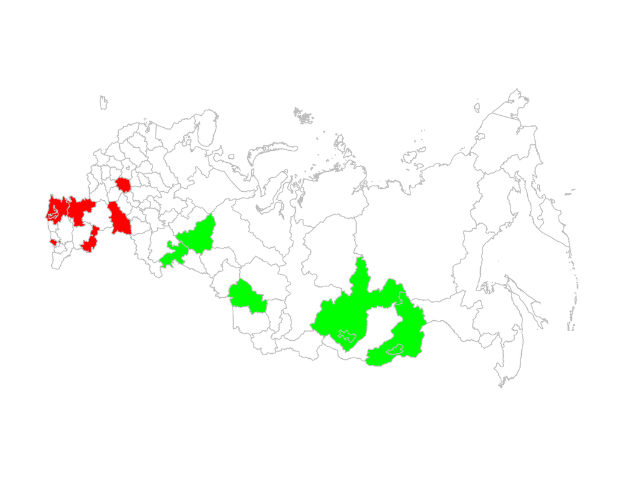